# R Notebook

# Simulation of the Latemar Carbonate platform

loading the functions, replace with the location of your files

```r
source("C:/Users/tl3315/Desktop/GitHub/AsymBiPGS/co_sim_condi.R")
source("C:/Users/tl3315/Desktop/GitHub/AsymBiPGS/cosim_functions.R")
```

Two libraries used that you first need to install with R

mvtnorm compute integral over Gaussian densities

```r
library(mvtnorm)
library(abind)
```

Getting the facies logs and transforming them into indicator variables

```r
env_lat<-data.matrix(read.table("depo_latemar.txt"))
diag_lat<-data.matrix(read.table("diag_latemar.txt"))
nz=nrow(env_lat)
e1<-e2<-e3<-e4<-d1<-d2<-d3<-matrix(0,nz,4)
e1[env_lat==1]=1
e2[env_lat==2]=1
e3[env_lat==3]=1
e4[env_lat==4]=1
d1[diag_lat==1]=1
d2[diag_lat==2]=1
d3[diag_lat==3]=1
e1[is.na(env_lat)]=e2[is.na(env_lat)]=e3[is.na(env_lat)]=e4[is.na(env_lat)]=NA
d1[is.na(diag_lat)]=d2[is.na(diag_lat)]=d3[is.na(diag_lat)]=NA
```

Computing proportions of the different facies in the logs

```r
pe1 = mean(e1,na.rm=TRUE)
pe2 = mean(e2,na.rm=TRUE)
pe3 = mean(e3,na.rm=TRUE)
pe4 = mean(e4,na.rm=TRUE)
c(pe1,pe2,pe3,pe4)
```

```
[1] 0.1720779 0.5227273 0.1525974 0.1525974
```

```r
pd1=mean(d1,na.rm=TRUE)
pd2=mean(d2,na.rm=TRUE)
pd3=mean(d3,na.rm=TRUE)
c(pd1,pd2,pd3)
```

```
[1] 0.89610390 0.05519481 0.04870130
```

```r
pd1e1=mean(d1*e1,na.rm=TRUE)/pe1
pd1e2=mean(d1*e2,na.rm=TRUE)/pe2
pd1e3=mean(d1*e3,na.rm=TRUE)/pe3
pd1e4=mean(d1*e4,na.rm=TRUE)/pe4
pd2e1=mean(d2*e1,na.rm=TRUE)/pe1
pd2e2=mean(d2*e2,na.rm=TRUE)/pe2
pd2e3=mean(d2*e3,na.rm=TRUE)/pe3
pd2e4=mean(d2*e4,na.rm=TRUE)/pe4
pd3e1=mean(d3*e1,na.rm=TRUE)/pe1
pd3e2=mean(d3*e2,na.rm=TRUE)/pe2
pd3e3=mean(d3*e3,na.rm=TRUE)/pe3
pd3e4=mean(d3*e4,na.rm=TRUE)/pe4
matrix(c(pd1e1,pd1e2,pd1e3,pd1e4,pd2e1,pd2e2,pd2e3,pd2e4,pd3e1,pd3e2,pd3e3,pd3e4),3,4,byrow=TRUE)
```

```
     [,1]       [,2]      [,3]      [,4]
[1,]    1 0.90062112 0.9787234 0.6808511
[2,]    0 0.09937888 0.0212766 0.0000000
[3,]    0 0.00000000 0.0000000 0.3191489
```

```r
pe1+pe2+pe3+pe4
```

```
[1] 1
```

Building the grids for the Earth models

Because there are two fields: depositional and diagenetic, there are two grids

```r
env_lat[is.na(env_lat)]=0 # with 0, the gibbs sampler will find random values
diag_lat[is.na(diag_lat)]=0
grid<-grid_co<-array(NA,c(100,10,91))
grid[5,8,]<-env_lat[,1]
grid[25,6,]<-env_lat[,2]
grid[35,3,]<-env_lat[,3]
grid[95,7,]<-env_lat[,4]
grid_co[5,8,]<-diag_lat[,1]
grid_co[25,6,]<-diag_lat[,2]
grid_co[35,3,]<-diag_lat[,3]
grid_co[95,7,]<-diag_lat[,4]
```

displaying an image with all the logs

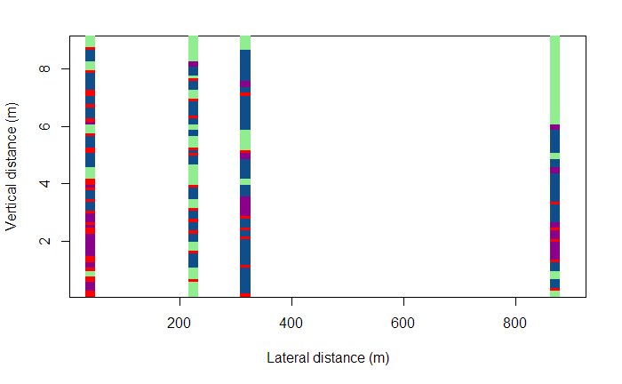

```r
# we are doubling the logs for a better visualization
im<-matrix(NA,100,91)
im[5,]<-env_lat[,1]
im[4,]<-env_lat[,1]
im[25,]<-env_lat[,2]
im[24,]<-env_lat[,2]
im[35,]<-env_lat[,3]
im[34,]<-env_lat[,3]
im[95,]<-env_lat[,4]
im[94,]<-env_lat[,4]
image(x=(1:100)*9.2,y=(1:91)/10,z=im,col=c("lightgreen","dodgerblue4","darkmagenta","red"),xlab="Lateral distance (m)",ylab="Vertical distance (m)")
```

print image

```r
png(file="logslate.png",width=4000,height = 2500,res=300,antialias = )
image(x=(1:100)*9.2,y=(1:91)/10,z=im,col=c("lightgreen","dodgerblue4","darkmagenta","red"),xlab="Lateral distance (m)",ylab="Vertical distance (m)")
```

Another image the environment of depositions and the diagenesis logs

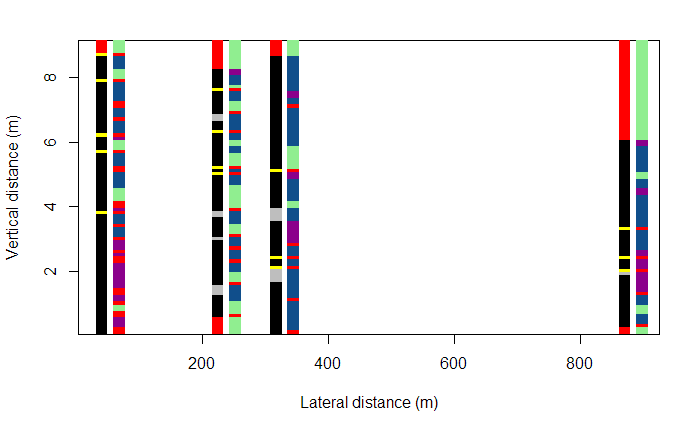

```r
im<-matrix(NA,100,91)
im[5,]<-diag_lat[,1]+4
im[4,]<-diag_lat[,1]+4
im[8,]<-env_lat[,1]
im[7,]<-env_lat[,1]
im[25,]<-diag_lat[,2]+4
im[24,]<-diag_lat[,2]+4
im[28,]<-env_lat[,2]
im[27,]<-env_lat[,2]
im[35,]<-diag_lat[,3]+4
im[34,]<-diag_lat[,3]+4
im[38,]<-env_lat[,3]
im[37,]<-env_lat[,3]
im[95,]<-diag_lat[,4]+4
im[94,]<-diag_lat[,4]+4
im[98,]<-env_lat[,4]
im[97,]<-env_lat[,4]
image(x=(1:100)*9.2,y=(1:91)/10,z=im,col=c("lightgreen","dodgerblue4","darkmagenta","red","black","grey","yellow"),xlab="Lateral distance (m)",ylab="Vertical distance (m)")
```

print image

```r
png(file="logslatediag2.png",width=4000,height = 2500,res=300,antialias = )
image(x=(1:100)*9.2,y=(1:91)/10,z=im,col=c("lightgreen","dodgerblue4","darkmagenta","red","black","grey","yellow"),ylab="Vertical distance (m)",xlab = "Lateral distance (m)")
```

Increasing the details of the section

```r
grid2<-grid_co2<-array(NA,c(100,10,182))
i=1
for (j in 1:182){

    grid2[5,8,j]<-env_lat[i,1]
    grid2[25,6,j]<-env_lat[i,2]
    grid2[35,3,j]<-env_lat[i,3]
    grid2[95,7,j]<-env_lat[i,4]
    grid_co2[5,8,j]<-diag_lat[i,1]
    grid_co2[25,6,j]<-diag_lat[i,2]
    grid_co2[35,3,j]<-diag_lat[i,3]
    grid_co2[95,7,j]<-diag_lat[i,4]
    if(j%%2==0){i=i+1}
}
```

3 dimensional simulation of the Latemar conditionned to the logs

```r
par(bg="transparent")
rv1=0.3
rv2=1.2
rhx1=rhy1=800
rhx2=rhy2=800
b1=0
b2=5
rho=0.6
shift=0.1
rho1a<-model(shift,rv1,b1)
warning(rho>rho1a)
```

```
FALSE
```

```r
alpha1=(rho/rho1a)^2
alpha2=1-(rho/rho1a)^2
rv3=0.2
rv4=0.3
rhx3=rhy3=800
rhx4=rhy4=800
b3=0
b4=0
e=-0.8
f=-0.5
a14=-0.1
a24=0.1
rho1a14 = model(a14,rv1,b1)
rho2a24=model(a24,rv2,b2)
#thresholds
q1=qnorm(pe1+pe2)
Sigma1 = matrix(c(1,rho,rho,1),2,2)
q2=0
obj = Inf
for ( test in 1:100 ){
  q2test = qnorm(test/100)
  newobj =abs( pmvnorm(lower=c(-Inf,-Inf),upper=c(q1,q2test),mean=c(0,0),sigma=Sigma1) - pe1 )
  if (newobj < obj){
    q2 = q2test
    obj = newobj
  }
}
q3=0
obj = Inf
for ( test in 1:100 ){
  q3test = qnorm(test/100)
  newobj =abs( pmvnorm(lower=c(q1,-Inf),upper=c(Inf,q3test),mean=c(0,0),sigma=Sigma1) - pe4 )
  if (newobj < obj){
    q3 = q3test
    obj = newobj
  }
}
c(q1,q2,q3)
```

```
[1]  0.5095174 -0.9153651  0.6744898
```

```r
Sigmad = diag(1,3)
qd2e2=0
qd2e3=0
qd1e4=0
obje2 = Inf
obje3 = Inf
obje4 = Inf
for ( test in 1:100 ){
  qd2e2test = qnorm(test/100)
  qd2e3test = qnorm(test/100)
  qd1e4test = qnorm(test/100)
  Sigmad[1,2]=Sigmad[2,1]=e*rho1a14
  Sigmad[1,3]=Sigmad[3,1]=e*(rho/rho1a)*model(a14-shift,rv1,b1)+f*sqrt(1-(rho/rho1a)^2)*model(a24,rv2,b2)
  Sigmad[2,3]=Sigmad[3,2]=rho
  newobje2 =abs( pmvnorm(lower=c(qd2e2test,-Inf,q2),upper=c(Inf,q1,Inf),mean=c(0,0,0),sigma=Sigmad)/pe2 - pd2e2 )
  newobje3 =abs( pmvnorm(lower=c(qd2e3test,q1,q3),upper=c(Inf,Inf,Inf),mean=c(0,0,0),sigma=Sigmad)/pe3 - pd2e3 )
  newobje4 =abs( pmvnorm(lower=c(qd1e4test,q1,-Inf),upper=c(Inf,Inf,q3),mean=c(0,0,0),sigma=Sigmad)/pe4 - pd3e4 )
  if (newobje2 < obje2){
    qd2e2 = qd2e2test
    obje2 = newobje2
  }
  if (newobje3 < obje3){
    qd2e3 = qd2e3test
    obje3 = newobje3
  }
  if (newobje4 < obje4){
    qd1e4 = qd1e4test
    obje4 = newobje4
  }
}
c(qd1e4,qd2e2,qd2e3)
```

```
[1] -0.1763742  1.1263911  0.3054808
```

```r
# here Y4 is not used
Y1<-sim3d(rv1,rhx1,rhy1,b1,100,0.05,182,10,100,25,10)
Y2<-sim3d(rv2,rhx2,rhy2,b2,100,0.05,182,10,100,25,10)
Y3<-sim3d(rv3,rhx3,rhy3,b3,100,0.05,182,10,100,25,10)
Y4<-sim3d(rv4,rhx4,rhy4,b4,100,0.05,182,10,100,25,10)
#careful to check that we put 0 to extend the gibbs sampling to where there is no data
simwell<-gibbs_sampling3d(grid2,grid_co2,c(q1,q2,q3),c(qd1e4,qd2e2,qd2e3),0.05,10,25,c(rv1,rv2,rv3,rv4),c(rhx1,rhx2,rhx3,rhx4),c(rhy1,rhy2,rhy3,rhy4),c(b1,b2,b3,b4),c(rho,e*model(a14,rv1,b1),f*model(a24,rv2,b2)),c(shift,a14,a24),50)
Y1well<-simwell[,,1:182]
Y2well<-Z2well<-simwell[,,183:364]
Y3well<-simwell[,,365:546]
Y4well<-Z4well<-simwell[,,547:728]
# back transformation of the Zi into Yi at the wells
# be VERY CAREFUL, we cannot put Y4 and Y2 in the same loop
for( z in 3:180){
  Y2well[,,z]=(Z2well[,,z]-(rho/rho1a)*Y1well[,,z+2])/sqrt(1-(rho^2)/(rho1a^2))
}
for( z in 3:180){
  Y4well[,,z]=(Z4well[,,z]-Y1well[,,z-2]*e-f*Y2well[,,z+2])/sqrt(1-(e^2)-(f^2))
}
Z1c =Y1 + dual_krig_surf(Y1well-Y1,rhx1,rhy1,10,25)
```

```
[1] 4
          [,1]      [,2]      [,3]      [,4]
[1,] 1.0000000 0.8553453 0.4675050 0.6661436
[2,] 0.8553453 1.0000000 0.4166295 0.7728316
[3,] 0.4675050 0.4166295 1.0000000 0.3245116
[4,] 0.6661436 0.7728316 0.3245116 1.0000000
            [,1]       [,2]        [,3]        [,4]
[1,]  3.94663066 -3.1185620 -0.53062823 -0.04670453
[2,] -3.11856196  5.1524624 -0.07898570 -1.87894386
[3,] -0.53062823 -0.0789857  1.28140542 -0.00131369
[4,] -0.04670453 -1.8789439 -0.00131369  2.48364542
```

```r
Z2c<-Y2c<-Y2 +dual_krig_surf(Y2well-Y2,rhx2,rhy2,10,25)
```

```
[1] 4
          [,1]      [,2]      [,3]      [,4]
[1,] 1.0000000 0.8553453 0.4675050 0.6661436
[2,] 0.8553453 1.0000000 0.4166295 0.7728316
[3,] 0.4675050 0.4166295 1.0000000 0.3245116
[4,] 0.6661436 0.7728316 0.3245116 1.0000000
            [,1]       [,2]        [,3]        [,4]
[1,]  3.94663066 -3.1185620 -0.53062823 -0.04670453
[2,] -3.11856196  5.1524624 -0.07898570 -1.87894386
[3,] -0.53062823 -0.0789857  1.28140542 -0.00131369
[4,] -0.04670453 -1.8789439 -0.00131369  2.48364542
```

```r
Z3c<-Y3 +dual_krig_surf(Y3well-Y3,rhx3,rhy3,10,25)
```

```
[1] 4
          [,1]      [,2]      [,3]      [,4]
[1,] 1.0000000 0.8553453 0.4675050 0.6661436
[2,] 0.8553453 1.0000000 0.4166295 0.7728316
[3,] 0.4675050 0.4166295 1.0000000 0.3245116
[4,] 0.6661436 0.7728316 0.3245116 1.0000000
            [,1]       [,2]        [,3]        [,4]
[1,]  3.94663066 -3.1185620 -0.53062823 -0.04670453
[2,] -3.11856196  5.1524624 -0.07898570 -1.87894386
[3,] -0.53062823 -0.0789857  1.28140542 -0.00131369
[4,] -0.04670453 -1.8789439 -0.00131369  2.48364542
```

```r
Z4c<-Y4c<-Y4 +dual_krig_surf(Y4well-Y4,rhx4,rhy4,10,25)
```

```
[1] 4
          [,1]      [,2]      [,3]      [,4]
[1,] 1.0000000 0.8553453 0.4675050 0.6661436
[2,] 0.8553453 1.0000000 0.4166295 0.7728316
[3,] 0.4675050 0.4166295 1.0000000 0.3245116
[4,] 0.6661436 0.7728316 0.3245116 1.0000000
            [,1]       [,2]        [,3]        [,4]
[1,]  3.94663066 -3.1185620 -0.53062823 -0.04670453
[2,] -3.11856196  5.1524624 -0.07898570 -1.87894386
[3,] -0.53062823 -0.0789857  1.28140542 -0.00131369
[4,] -0.04670453 -1.8789439 -0.00131369  2.48364542
```

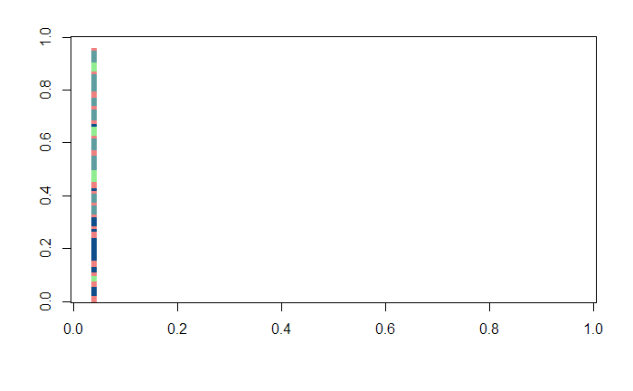

```r
for( z in 3:180){
  Z2c[,,z]=Y2c[,,z]*sqrt(1-(rho^2)/(rho1a^2))+Z1c[,,z+2]*(rho)/(rho1a)
}
for( z in 3:180){
  Z4c[,,z]=Y4c[,,z]*sqrt(1-(e^2)-(f^2))+Z1c[,,z-2]*e+f*Y2c[,,z+2]
}
faciesenv<-faciesdiag<-Z1c
faciesenv[Z1c<q1 & Z2c<q2]=1
faciesenv[Z1c<q1 & Z2c>q2]=2
faciesenv[Z1c>q1 & Z2c<q3]=4
faciesenv[Z1c>q1 & Z2c>q3]=3
faciesdiag[]=1
faciesdiag[Z1c>q1 & Z2c<q3 & Z4c>qd1e4]=3
faciesdiag[Z1c<q1 & Z2c>q2 & Z4c>qd2e2]=2
faciesdiag[Z1c>q1 & Z2c>q3 & Z4c>qd2e3]=2
col_env <- c("lightgreen","cadetblue","dodgerblue4","lightcoral")
griddata<-grid2
griddata[griddata==0]=NA
W<-image(griddata[,8,],col = col_env)
```

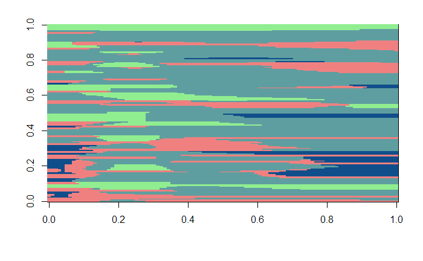

```r
W<-image(faciesenv[,8,],col = col_env)
```

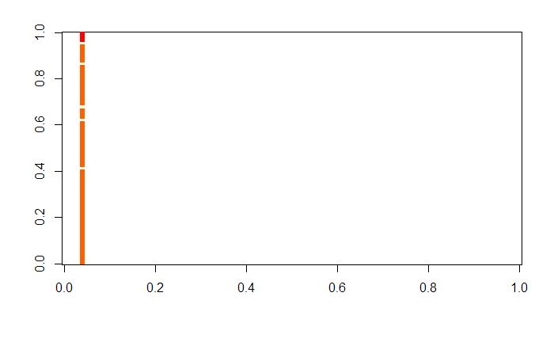

```r
W<-image(grid_co2[,8,])
```

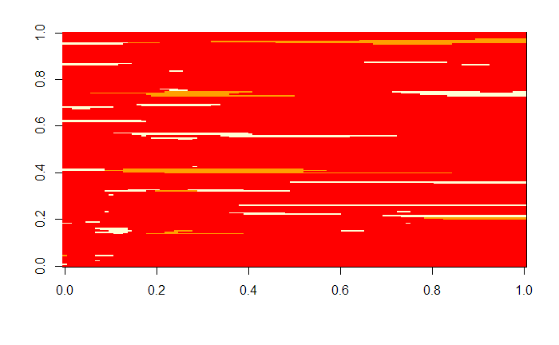

```r
W<-image(faciesdiag[,8,])
```

computing transiograms on the realization

```r
i1real<-i2real<-i3real<-i4real<-faciesenv
i1real[faciesenv!=1]=0
i2real[faciesenv==2]=1
i2real[faciesenv!=2]=0
i3real[faciesenv==3]=1
i3real[faciesenv!=3]=0
i4real[faciesenv==4]=1
i4real[faciesenv!=4]=0
t11real3=tr_3d_vert(i1real,i1real,60)
t12real3=tr_3d_vert(i1real,i2real,60)
t13real3=tr_3d_vert(i1real,i3real,60)
t14real3=tr_3d_vert(i1real,i4real,60)
t21real3=tr_3d_vert(i2real,i1real,60)
t22real3=tr_3d_vert(i2real,i2real,60)
t23real3=tr_3d_vert(i2real,i3real,60)
t24real3=tr_3d_vert(i2real,i4real,60)
t31real3=tr_3d_vert(i3real,i1real,60)
t32real3=tr_3d_vert(i3real,i2real,60)
t33real3=tr_3d_vert(i3real,i3real,60)
t34real3=tr_3d_vert(i3real,i4real,60)
t41real3=tr_3d_vert(i4real,i1real,60)
t42real3=tr_3d_vert(i4real,i2real,60)
t43real3=tr_3d_vert(i4real,i3real,60)
t44real3=tr_3d_vert(i4real,i4real,60)

z = (1:60)/20.
png(file="laterealtransio.png",width=2000,height = 1600,res=300)
par(mar=c(2,3,1,1),mfrow=c(4,4))
plot(z,t11real)
title(main=expression(paste('t'[e1e1],"(h)")),line=-1)
plot(z,t12real)
title(main=expression(paste('t'[e1e2],"(h)")),line=-1)
plot(z,t13real)
title(main=expression(paste('t'[e1e3],"(h)")),line=-1)
plot(z,t14real)
title(main=expression(paste('t'[e1e4],"(h)")),line=-1)
plot(z,t21real)
title(main=expression(paste('t'[e2e1],"(h)")),line=-1)
plot(z,t22real)
title(main=expression(paste('t'[e2e2],"(h)")),line=-1)
plot(z,t23real)
title(main=expression(paste('t'[e2e3],"(h)")),line=-1)
plot(z,t24real)
title(main=expression(paste('t'[e2e4],"(h)")),line=-1)
plot(z,t31real)
title(main=expression(paste('t'[e3e1],"(h)")),line=-1)
plot(z,t32real)
title(main=expression(paste('t'[e3e2],"(h)")),line=-1)
plot(z,t33real)
title(main=expression(paste('t'[e3e3],"(h)")),line=-1)
plot(z,t34real)
title(main=expression(paste('t'[e3e4],"(h)")),line=-1)
plot(z,t41real)
title(main=expression(paste('t'[e4e1],"(h)")),line=-1)
plot(z,t42real)
title(main=expression(paste('t'[e4e2],"(h)")),line=-1)
plot(z,t43real)
title(main=expression(paste('t'[e4e3],"(h)")),line=-1)
plot(z,t44real)
title(main=expression(paste('t'[e4e4],"(h)")),line=-1)
```

Computing the average over three realizations

```r
t11reals=(t11real+t11real2+t11real3)/3
t12reals=(t12real+t12real2+t12real3)/3
t13reals=(t13real+t13real2+t13real3)/3
t14reals=(t14real+t14real2+t14real3)/3
t21reals=(t21real+t21real2+t21real3)/3
t22reals=(t22real+t22real2+t22real3)/3
t23reals=(t23real+t23real2+t23real3)/3
t24reals=(t24real+t24real2+t24real3)/3
t31reals=(t31real+t31real2+t31real3)/3
t32reals=(t32real+t32real2+t32real3)/3
t33reals=(t33real+t33real2+t33real3)/3
t34reals=(t34real+t34real2+t34real3)/3
t41reals=(t41real+t41real2+t41real3)/3
t42reals=(t42real+t42real2+t42real3)/3
t43reals=(t43real+t43real2+t43real3)/3
t44reals=(t44real+t44real2+t44real3)/3
```

and also transigorams with the diagenetic facies

```r
d1real<-d2real<-d3real<-faciesdiag
d1real[faciesdiag!=1]=0
d2real[faciesdiag==2]=1
d2real[faciesdiag!=2]=0
d3real[faciesdiag==3]=1
d3real[faciesdiag!=3]=0
td3e1real3=tr_3d_vert(d3real,i1real,60)
td3e2real3=tr_3d_vert(d3real,i2real,60)
td3e3real3=tr_3d_vert(d3real,i3real,60)
td3e4real3=tr_3d_vert(d3real,i4real,60)
td2e1real3=tr_3d_vert(d2real,i1real,60)
td2e2real3=tr_3d_vert(d2real,i2real,60)
td2e3real3=tr_3d_vert(d2real,i3real,60)
td2e4real3=tr_3d_vert(d2real,i4real,60)
td3d3real3=tr_3d_vert(d3real,d3real,60)
td2d3real3=tr_3d_vert(d2real,d3real,60)
td3d2real3=tr_3d_vert(d3real,d2real,60)
td2d2real3=tr_3d_vert(d2real,d2real,60)
```

Creating a text file for exporting the realizations

```r
for ( z in 1:182){
  for ( y in 1:10){
    for ( x in 1:100){
      write(toString(c(faciesenv[x,y,z])),"latemarcondenvres6.csv",append=TRUE)
      write(toString(c(faciesdiag[x,y,z])),"latemarconddiagres.csv",append=TRUE)
    }
  }
}
```

Environments and diagenesis are also combined in a single model

```r
combined<-faciesenv
combined[faciesdiag==2]=5
combined[faciesdiag==3]=6
for ( z in 1:182){
  for ( y in 1:10){
    for ( x in 1:100){
      write(toString(c(combined[x,y,z])),"latemarcombined4.csv",append=TRUE)
    }
  }
}
```

Exporting the data in three dimensions

```r
griddata<-grid
griddata[griddata==0]=NA
gridcodata<-grid_co
gridcodata[gridcodata==0]=NA

for ( z in 1:91){
  for ( y in 1:10){
    for ( x in 1:100){
      write(toString(c(griddata[x,y,z])),"dataenv.csv",append=TRUE)
      write(toString(c(gridcodata[x,y,z])),"datadiag.csv",append=TRUE)
    }
  }
}
```

data with all facies

```r
griddata<-grid
griddata[griddata==0]=NA
gridcodata<-grid_co
gridcodata[gridcodata==0]=NA
combineddata<-griddata
combineddata[gridcodata==2]=5
combineddata[gridcodata==3]=6
for ( z in 1:91){
  for ( y in 1:10){
    for ( x in 1:100){
      write(toString(c(combineddata[x,y,z])),"latemarcombineddata.csv",append=TRUE)
    }
  }
}
```

computing the embedded transitions of one realization

```r
i1real<-i2real<-i3real<-i4real<-faciesenv
i1real[faciesenv!=1]=0
i2real[faciesenv==2]=1
i2real[faciesenv!=2]=0
i3real[faciesenv==3]=1
i3real[faciesenv!=3]=0
i4real[faciesenv==4]=1
i4real[faciesenv!=4]=0
r12=embedded3d(i1real,i2real)
r13=embedded3d(i1real,i3real)
r14=embedded3d(i1real,i4real)
r21=embedded3d(i2real,i1real)
r23=embedded3d(i2real,i3real)
r24=embedded3d(i2real,i4real)
r31=embedded3d(i3real,i1real)
r32=embedded3d(i3real,i2real)
r34=embedded3d(i3real,i4real)
r41=embedded3d(i4real,i1real)
r42=embedded3d(i4real,i2real)
r43=embedded3d(i4real,i3real)
matrix(c(0,r12,r13,r14,r21,0,r23,r24,r31,r32,0,r34,r41,r42,r43,0),4,4,byrow=TRUE)
```

```r
real7<-matrix(c(0,r12,r13,r14,r21,0,r23,r24,r31,r32,0,r34,r41,r42,r43,0),4,4,byrow=TRUE)
```

```r
(real1+real2+real3+real4+real5+real6)/6
```

and the data

```r
r12d=embedded2d(e1,e2)
r13d=embedded2d(e1,e3)
r14d=embedded2d(e1,e4)
s1=r12d+r13d+r14d
r21d=embedded2d(e2,e1)
r23d=embedded2d(e2,e3)
r24d=embedded2d(e2,e4)
s2=r21d+r23d+r24d
r31d=embedded2d(e3,e1)
r32d=embedded2d(e3,e2)
r34d=embedded2d(e3,e4)
s3=r31d+r32d+r34d
r41d=embedded2d(e4,e1)
r42d=embedded2d(e4,e2)
r43d=embedded2d(e4,e3)
s4=r41d+r42d+r43d
matrix(c(0,r12d/s1,r13d/s1,r14d/s1,r21d/s2,0,r23d/s2,r24d/s2,r31d/s3,r32d/s3,0,r34d/s3,r41d/s4,r42d/s4,r43d/s4,0),4,4,byrow=TRUE)
```

we also compute the transiograms on the final model

```r
real1<-real2<-real3<-real4<-faciesenv
real1[faciesenv!=1]=0
real2[faciesenv==2]=1
real2[faciesenv!=2]=0
real3[faciesenv==3]=1
real3[faciesenv!=3]=0
real4[faciesenv==4]=1
real4[faciesenv!=4]=0
t11real<-tr_3d_vert(real1,real1,50)
t12real<-tr_3d_vert(real1,real2,50)
t13real<-tr_3d_vert(real1,real3,50)
t14real<-tr_3d_vert(real1,real4,50)
t21real<-tr_3d_vert(real2,real1,50)
t22real<-tr_3d_vert(real2,real2,50)
t23real<-tr_3d_vert(real2,real3,50)
t24real<-tr_3d_vert(real2,real4,50)
t31real<-tr_3d_vert(real3,real1,50)
t32real<-tr_3d_vert(real3,real2,50)
t33real<-tr_3d_vert(real3,real3,50)
t34real<-tr_3d_vert(real3,real4,50)
t41real<-tr_3d_vert(real4,real1,50)
t42real<-tr_3d_vert(real4,real2,50)
t43real<-tr_3d_vert(real4,real3,50)
t44real<-tr_3d_vert(real4,real4,50)
par(mfrow=c(4,4))
plot(50,t11real)
plot(length(t44real),t12real)
plot(length(t44real),t13real)
plot(length(t44real),t14real)
plot(length(t44real),t21real)
plot(length(t44real),t22real)
plot(length(t44real),t23real)
plot(length(t44real),t24real)
plot(length(t44real),t31real)
plot(length(t44real),t32real)
plot(length(t44real),t33real)
plot(length(t44real),t34real)
plot(length(t44real),t41real)
plot(length(t44real),t42real)
plot(length(t44real),t43real)
plot(length(t44real),t44real)
```